# From customer response models to a price recommendation

## 3 · Reduction Depth

**Purpose:** Estimates retained day and line coverage among trips labeled `partial`. Reduction depth is derived as the complement of retained coverage, so a lower predicted coverage fraction represents a deeper reduction.

$$ \text{reduction depth} = 1-\text{retained coverage} $$

**Design Notes:**

1. **Two Coverage Components.** A trip may reduce covered days, covered lines, or both.
   - Day coverage: `days_bought / days_traveled`
   - Line coverage: `lines_active / lines_traveling`

   The model directly predicts these retained-coverage proportions. Their complements represent day- and line-reduction depth.
2. **Exposure Weighting.** Each target is weighted by its relevant denominator.
   - Day coverage is weighted by `days_traveled`.
   - Line coverage is weighted by `lines_traveling`.
   - This gives observations with greater statistical exposure proportionately more influence during fitting.
3. **Estimation Method.** Each component uses a flexible non-price baseline followed by a constrained parametric price term.
   - The baseline stage fits a gradient-boosted regression model to the logit-transformed coverage proportion using exposure-weighted squared-error loss.
   - This is an approximation rather than a true binomial-deviance tree model.
   - The baseline model is fitted only on standard-price, partial-coverage trips.
   - The price stage is then fitted across all development-period partial-coverage trips using an exposure-weighted Bernoulli log-likelihood.
4. **Connection to the State Model.** The Magnitude Model uses the same separation principle as the State Model, although the two models do not have identical architectures.
   - Non-price features estimate the baseline relationship.
   - Price enters separately through a simple parametric term.
   - Fitting the baseline models across all prices could allow region and month to absorb variation intended for the price term.
5. **Price-Response Constraints.** The base price coefficient is constrained to be nonpositive, preventing a higher price from increasing retained coverage for consumer accounts.
   - A business-account interaction is estimated separately.
   - The combined base and business effects are checked for every trip.
   - If more than 1% of trips have a positive combined price effect, the model is refitted with the business interaction fixed at zero.
   - The final fitted curves are checked across the complete candidate-price grid.
6. **Boundary Interpretation.** A coefficient at its imposed bound indicates that the constraint is active. It does not, by itself, prove that the parameter is unidentified.
   - A boundary estimate may reflect sparse outcome variation, instability, model misspecification, or an unconstrained optimum outside the permitted range.
   - Boundary estimates are therefore described as constraint-sensitive and are not interpreted as stable learned effects without additional validation.
7. **Validation.** Day and line coverage require separate evaluation because their outcome support differs materially.
   - The complete day model is compared with a constant prediction based on the development-period mean.
   - This comparison evaluates the combined tree and price model; it does not isolate the tree’s incremental contribution.
   - Establishing that contribution would require separate comparisons of constant, price-only, tree-only, and tree-plus-price specifications.
   - The line component requires its own held-out comparison of predicted and observed mean coverage, error, reduction frequency, performance by observed price, and sensitivity to the coefficient bounds.

**Observations:**

```python
# Fit Reduction Depth
def logit(p):
    p = np.clip(p, 1e-4, 1 - 1e-4)

    return np.log(p / (1 - p))


def expit(z):
    return 1.0 / (1.0 + np.exp(-z))


def fit_coverage(
    target_col,
    denom_col,
    label,
    lower_bound,
):
    partial = trips['y'].eq('partial').to_numpy()
    baseline_rows = partial & tr & STD
    price_rows = partial & tr

    denominator = (
        trips[denom_col]
        .to_numpy()
        .clip(1)
    )

    coverage = (
        trips[target_col].to_numpy()
        / denominator
    )

    base = HistGradientBoostingRegressor(
        max_iter = 300,
        learning_rate = 0.06,
        max_leaf_nodes = 15,
        min_samples_leaf = 40,
        l2_regularization = 1.0,
        early_stopping = True,
        validation_fraction = 0.15,
        random_state = 0,
    ).fit(
        X[baseline_rows],
        logit(coverage[baseline_rows]),
        sample_weight = denominator[baseline_rows],
    )

    baseline_prediction = base.predict(X[price_rows])
    log_price = trips.loc[
        price_rows, 'log_price'
    ].to_numpy()

    business = trips.loc[
        price_rows, 'is_business'
    ].to_numpy(dtype = float)

    observed = coverage[price_rows]
    weights = denominator[price_rows]

    def loss(theta):
        linear_prediction = (
            baseline_prediction
            + theta[0] * log_price
            + theta[1] * log_price * business
        )

        predicted = expit(linear_prediction)
        predicted = np.clip(
            predicted,
            1e-9,
            1 - 1e-9,
        )

        weighted_loss = weights * (
            observed * np.log(predicted)
            + (1 - observed) * np.log(1 - predicted)
        )

        return -weighted_loss.sum() / weights.sum()

    result = minimize(
        loss,
        np.zeros(2),
        method = 'L-BFGS-B',
        bounds = [
            (lower_bound, 0),
            (-4, 4),
        ],
        options = {'maxiter': 400},
    )

    if not result.success:
        raise RuntimeError(
            f'{label} fit did not converge: {result.message}'
        )

    theta = result.x
    net_effect = (
        theta[0]
        + theta[1] * business
    )

    interaction_retained = (
        (net_effect > 0).mean() <=  0.01
    )

    if not interaction_retained:
        result = minimize(
            loss,
            np.zeros(2),
            method = 'L-BFGS-B',
            bounds = [
                (lower_bound, 0),
                (0, 0),
            ],
            options = {'maxiter': 400},
        )

        if not result.success:
            raise RuntimeError(
                f'{label} constrained refit did not converge: '
                f'{result.message}'
            )

        theta = result.x
        net_effect = (
            theta[0]
            + theta[1] * business
        )

    diagnostics = {
        'Measure': label,
        'Baseline Trips': baseline_rows.sum(),
        'Price-Fit Trips': price_rows.sum(),
        'Price Coefficient': theta[0],
        'Business Interaction': theta[1],
        'Minimum Net Effect': net_effect.min(),
        'Median Net Effect': np.median(net_effect),
        'Maximum Net Effect': net_effect.max(),
        'Wrong-Signed Share': (net_effect > 0).mean(),
        'Interaction': (
            'Retained'
            if interaction_retained
            else 'Removed'
        ),
        'Bound Status': (
            'Active'
            if np.isclose(
                theta[0],
                lower_bound,
                atol = 1e-6,
            )
            else 'Not active'
        ),
    }

    return base, theta, diagnostics


partial = trips['y'].eq('partial')
line_cut_share = (
    partial
    & trips['lines_active'].lt(
        trips['lines_traveling']
    )
).sum() / max(partial.sum(), 1)

day_base, day_theta, day_diagnostics = fit_coverage(
    target_col = 'days_bought',
    denom_col = 'days_traveled',
    label = 'Day coverage',
    lower_bound = -5.0,
)

line_base, line_theta, line_diagnostics = fit_coverage(
    target_col = 'lines_active',
    denom_col = 'lines_traveling',
    label = 'Line coverage',
    lower_bound = -1.5,
)

fit_diagnostics = pd.DataFrame([
    day_diagnostics,
    line_diagnostics,
])

display(
    fit_diagnostics.style
    .hide(axis = 'index')
    .format({
        'Baseline Trips': '{:,.0f}',
        'Price-Fit Trips': '{:,.0f}',
        'Price Coefficient': '{:+.3f}',
        'Business Interaction': '{:+.3f}',
        'Minimum Net Effect': '{:+.3f}',
        'Median Net Effect': '{:+.3f}',
        'Maximum Net Effect': '{:+.3f}',
        'Wrong-Signed Share': '{:.1%}',
    })
    .bar(
        subset = ['Price Coefficient'],
        align = 'mid',
        color = [
            'rgba(227, 73, 72, 0.45)',
            'rgba(42, 120, 214, 0.45)',
        ],
        vmin = -5,
        vmax = 5,
    )
    .bar(
        subset = ['Business Interaction'],
        align = 'mid',
        color = [
            'rgba(227, 73, 72, 0.45)',
            'rgba(42, 120, 214, 0.45)',
        ],
        vmin = -4,
        vmax = 4,
    )
    .set_caption('Reduction-Depth Model Diagnostics')
    .set_properties(**{'text-align': 'left'})
    .set_table_styles(TABLE_STYLES)
)

support_summary = pd.DataFrame({
    'Measure': ['Partial trips with line reductions'],
    'Result': [line_cut_share],
    'Interpretation': [
        'Observed support for the line-coverage model'
    ],
})

display(
    support_summary.style
    .hide(axis = 'index')
    .format({'Result': '{:.1%}'})
    .bar(
        subset = ['Result'],
        color = 'rgba(42, 120, 214, 0.45)',
        vmin = 0,
        vmax = 0.25,
    )
    .set_caption('Line-Reduction Data Support')
    .set_properties(**{'text-align': 'left'})
    .set_table_styles(TABLE_STYLES)
)


def predict_coverage(
    base,
    theta,
    Xf,
    df,
    mult = None,
):
    if mult is None:
        log_price = df['log_price'].to_numpy()
    else:
        log_price = np.full(
            len(df),
            np.log(float(mult)),
        )

    linear_prediction = (
        base.predict(Xf)
        + theta[0] * log_price
        + theta[1]
        * log_price
        * df['is_business'].to_numpy(dtype = float)
    )

    return np.clip(
        expit(linear_prediction),
        0.02,
        1.0,
    )
```

Reduction-Depth Model Diagnostics

| Measure | Baseline Trips | Price-Fit Trips | Price Coefficient | Business Interaction | Minimum Net Effect | Median Net Effect | Maximum Net Effect | Wrong-Signed Share | Interaction | Bound Status |
| --- | --- | --- | --- | --- | --- | --- | --- | --- | --- | --- |
| Day coverage | 5,471 | 9,257 | -3.336 | +1.142 | -3.336 | -2.194 | -2.194 | 0.0% | Retained | Not active |
| Line coverage | 5,471 | 9,257 | -1.500 | -4.000 | -5.500 | -5.500 | -1.500 | 0.0% | Retained | Active |

Line-Reduction Data Support

| Measure | Result | Interpretation |
| --- | --- | --- |
| Partial trips with line reductions | 6.8% | Observed support for the line-coverage model |

Held-Out Day-Coverage Validation

| Method | MAE | R² | Mean Prediction | Observed Mean | Mean Gap | Assessment |
| --- | --- | --- | --- | --- | --- | --- |
| Reduction-depth model | 0.1239 | 0.0032 | 49.6% | 50.7% | -1.1% | Review |
| Train-mean benchmark | 0.1228 | -0.0083 | 49.4% | 50.7% | -1.4% | Benchmark |

Held-Out Line-Coverage Validation

| Test Trips | Mean Prediction | Observed Mean | Mean Gap | MAE | Trips Reducing Lines |
| --- | --- | --- | --- | --- | --- |
| 2,221 | 100.0% | 97.1% | +2.8% | 0.0288 | 6.1% |

Predicted Day Coverage at Selected Prices

| Price Multiplier | Predicted Day Coverage |
| --- | --- |
| 0.90 | 56.9% |
| 1.00 | 49.9% |
| 1.20 | 38.0% |

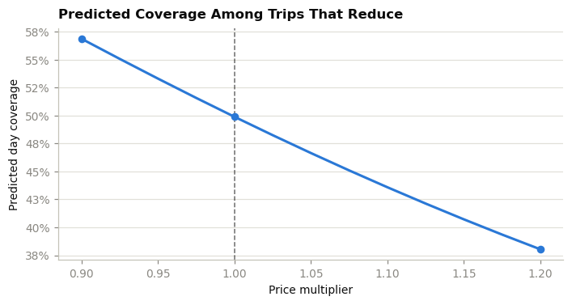

```python
# Validate Reduction-Depth Models
partial_test = (
    trips['y'].eq('partial')
    & te
).to_numpy()

test_partial_trips = trips[partial_test]

observed_day_coverage = (
    test_partial_trips['days_bought']
    / test_partial_trips['days_traveled']
).to_numpy()

predicted_day_coverage = predict_coverage(
    day_base,
    day_theta,
    X[partial_test],
    test_partial_trips,
)

train_partial = (
    trips['y'].eq('partial')
    & tr
)

train_mean_coverage = (
    trips.loc[train_partial, 'days_bought']
    / trips.loc[train_partial, 'days_traveled']
).mean()

constant_prediction = np.full_like(
    observed_day_coverage,
    train_mean_coverage,
)

model_mae = mean_absolute_error(
    observed_day_coverage,
    predicted_day_coverage,
)

constant_mae = mean_absolute_error(
    observed_day_coverage,
    constant_prediction,
)

day_model_passes = model_mae < constant_mae

day_validation = pd.DataFrame({
    'Method': [
        'Reduction-depth model',
        'Train-mean benchmark',
    ],
    'MAE': [
        model_mae,
        constant_mae,
    ],
    'R²': [
        r2_score(
            observed_day_coverage,
            predicted_day_coverage,
        ),
        r2_score(
            observed_day_coverage,
            constant_prediction,
        ),
    ],
    'Mean Prediction': [
        predicted_day_coverage.mean(),
        train_mean_coverage,
    ],
    'Observed Mean': [
        observed_day_coverage.mean(),
        observed_day_coverage.mean(),
    ],
    'Mean Gap': [
        predicted_day_coverage.mean()
        - observed_day_coverage.mean(),
        train_mean_coverage
        - observed_day_coverage.mean(),
    ],
    'Assessment': [
        'Pass' if day_model_passes else 'Review',
        'Benchmark',
    ],
})

display(
    day_validation.style
    .hide(axis = 'index')
    .format({
        'MAE': '{:.4f}',
        'R²': '{:.4f}',
        'Mean Prediction': '{:.1%}',
        'Observed Mean': '{:.1%}',
        'Mean Gap': '{:+.1%}',
    })
    .bar(
        subset = ['Mean Gap'],
        align = 'mid',
        color = [
            'rgba(227, 73, 72, 0.45)',
            'rgba(42, 120, 214, 0.45)',
        ],
        vmin = -0.05,
        vmax = 0.05,
    )
    .set_caption(
        'Held-Out Day-Coverage Validation'
    )
    .set_properties(**{'text-align': 'left'})
    .set_properties(
        subset = ['Assessment'],
        **{
            'color': (
                '#237a3b'
                if day_model_passes
                else RED
            ),
            'font-weight': 'bold',
        },
    )
    .set_table_styles(TABLE_STYLES)
)

observed_line_coverage = (
    test_partial_trips['lines_active']
    / test_partial_trips[
        'lines_traveling'
    ].clip(lower = 1)
).to_numpy()

predicted_line_coverage = predict_coverage(
    line_base,
    np.zeros(2),
    X[partial_test],
    test_partial_trips,
)

line_validation = pd.DataFrame({
    'Test Trips': [len(test_partial_trips)],
    'Mean Prediction': [
        predicted_line_coverage.mean()
    ],
    'Observed Mean': [
        observed_line_coverage.mean()
    ],
    'Mean Gap': [
        predicted_line_coverage.mean()
        - observed_line_coverage.mean()
    ],
    'MAE': [
        mean_absolute_error(
            observed_line_coverage,
            predicted_line_coverage,
        )
    ],
    'Trips Reducing Lines': [
        (
            observed_line_coverage < 0.999
        ).mean()
    ],
})

display(
    line_validation.style
    .hide(axis = 'index')
    .format({
        'Test Trips': '{:,.0f}',
        'Mean Prediction': '{:.1%}',
        'Observed Mean': '{:.1%}',
        'Mean Gap': '{:+.1%}',
        'MAE': '{:.4f}',
        'Trips Reducing Lines': '{:.1%}',
    })
    .bar(
        subset = ['Trips Reducing Lines'],
        color = 'rgba(42, 120, 214, 0.45)',
        vmin = 0,
        vmax = 0.25,
    )
    .set_caption(
        'Held-Out Line-Coverage Validation'
    )
    .set_properties(**{'text-align': 'left'})
    .set_table_styles(TABLE_STYLES)
)

coverage_curve = np.array([
    predict_coverage(
        day_base,
        day_theta,
        X[partial_test],
        test_partial_trips,
        multiplier,
    ).mean()
    for multiplier in GRID
])

monotonicity_violations = int(
    (np.diff(coverage_curve) > 1e-9).sum()
)

assert monotonicity_violations ==  0, (
    'predicted coverage increases somewhere '
    'in the price sweep'
)

selected_prices = [0.90, 1.00, 1.20]

curve_summary = pd.DataFrame({
    'Price Multiplier': selected_prices,
    'Predicted Day Coverage': [
        np.interp(
            multiplier,
            GRID,
            coverage_curve,
        )
        for multiplier in selected_prices
    ],
})

display(
    curve_summary.style
    .hide(axis = 'index')
    .format({
        'Price Multiplier': '{:.2f}',
        'Predicted Day Coverage': '{:.1%}',
    })
    .bar(
        subset = ['Predicted Day Coverage'],
        color = 'rgba(42, 120, 214, 0.45)',
        vmin = 0,
        vmax = 1,
    )
    .set_caption(
        'Predicted Day Coverage at Selected Prices'
    )
    .set_properties(**{'text-align': 'left'})
    .set_table_styles(TABLE_STYLES)
)

fig, ax = plt.subplots(
    figsize = (6.5, 3.5),
)

ax.plot(
    GRID,
    coverage_curve,
    color = ACCENT,
    linewidth = 2,
)

ax.scatter(
    selected_prices,
    [
        np.interp(
            multiplier,
            GRID,
            coverage_curve,
        )
        for multiplier in selected_prices
    ],
    color = ACCENT,
    s = 28,
    zorder = 3,
)

ax.axvline(
    1.0,
    color = INK,
    linestyle = '--',
    linewidth = 1,
    alpha = 0.60,
)

ax.set(
    xlabel = 'Price multiplier',
    ylabel = 'Predicted day coverage',
)

ax.set_title(
    'Predicted Coverage Among Trips That Reduce',
    loc = 'left',
    fontweight = 'bold',
    pad = 8,
)

ax.yaxis.set_major_formatter(
    lambda value, position: f'{value:.0%}'
)

ax.grid(
    axis = 'y',
    color = GRIDLINE,
    linewidth = 0.8,
)

plt.tight_layout()
plt.show()
```

## 4 · Partial-Label False Positives and Reduction-Depth Sensitivity

**Purpose:** Measures how false positives in the reconstructed `partial` label affect estimated day-reduction depth and defines a stronger-depth sensitivity for the revenue simulation.

**Design Notes:**

1. **Scope of the Diagnostic.** This section evaluates false positives among trips labeled `partial`.
   - It does not measure false negatives, confusion between every pair of states, or the overall accuracy of the State Model.
   - It measures how including trips that are not truly partial changes the conditional day-coverage target used by the Magnitude Model.
2. **Use of Synthetic Truth.** The synthetic dataset contains a latent state that identifies which labeled partial trips were generated from the true partial state.
   - This latent field is excluded from both predictive models.
   - It is used only for this diagnostic and the resulting simulation sensitivity.
   - In an operational dataset without a latent state, this source of label error would not be directly measurable.
3. **Development-Period Estimation.** The sensitivity factor is estimated using partial-coverage trips from months 0 through 19.
   - Months 20 through 23 remain outside the calculation.
   - The test period may be used to report whether the estimated bias remains similar over time, but it is not used to construct the simulation factor.
4. **Bias Direction.** The Magnitude Model predicts retained day coverage: $$ \text{day coverage} = \frac{\text{days bought}}{\text{days traveled}} $$

   Day-reduction depth is its complement:

   $$ \text{day-reduction depth} = 1-\text{day coverage} $$

   False-positive partial labels represent shallower reductions on average than trips generated from the true partial state. Including them raises observed retained coverage, reduces measured reduction depth, and can bias expected partial-state revenue upward.
5. **Weighting.** The diagnostic reports two versions of the difference:
   - A trip-weighted comparison, which gives every partial-coverage trip equal weight
   - A day-exposure-weighted comparison, which weights trips by `days_traveled`

   The day-exposure-weighted result is used for the simulation sensitivity because it is more closely aligned with the Magnitude Model’s fitting objective and the revenue associated with covered days.
6. **Sensitivity Calculation.** The stronger-depth multiplier is calculated as: $$ \text{depth sensitivity} = \frac{\text{mean day-reduction depth among true partial trips}} {\text{mean day-reduction depth among all labeled partial trips}} $$
   - `depth_scale = 1.00` uses the depth estimated from the reconstructed labels.
   - `depth_scale =` **1.04** applies the stronger day-reduction sensitivity estimated from the synthetic latent state.
   - The factor is applied only to day-reduction depth.
   - Line coverage is left unchanged because the day-derived factor does not establish an equivalent bias in the line component.
7. **Interpretation.** The multiplier is a sensitivity assumption, not a correction to known truth or a statistical bound on the outcome. It shows how the revenue result changes if true partial trips reduce day coverage more deeply than the reconstructed labels suggest.
8. **Uncertainty.** A bootstrap interval is calculated for the development-period depth-sensitivity multiplier. This interval describes sampling uncertainty in the diagnostic; it does not capture uncertainty in the synthetic data-generating assumptions.

**Observations:**

1. In the development period, the reconstructed partial-coverage rule has a precision of **77.4%**: **2,093** of **9,257** labeled partial trips are false positives.
2. False-positive partial trips have higher retained day coverage than trips generated from the true partial state:
   - True partial trips: **0.4648**
   - All labeled partial trips: **0.4935**
   - False-positive partial trips: **0.5918**
3. The trip-weighted difference in retained coverage is **2.9 percentage points**.
4. The day-exposure-weighted mean reduction depth is **0.5433** among true partial trips and **0.5220** among all labeled partial trips.
5. The resulting stronger-depth sensitivity multiplier is **1.04×**, with a 95% bootstrap interval of **1.03× to 1.05×**.
6. This multiplier applies only to predicted day-reduction depth. It is carried into the simulation alongside the unadjusted `1.00` case so the revenue effect of partial-label false positives remains visible.

```python
# Measure Label Contamination
development_mask = tr

truth_state = trips['state'].replace({
    'substitutes': 'null',
    'leaves': 'null',
})

labeled_partial = (
    trips['y'].eq('partial').to_numpy()
    & development_mask
)

true_partial = (
    labeled_partial
    & truth_state.eq('partial').to_numpy()
)

false_positive = (
    labeled_partial
    & ~truth_state.eq('partial').to_numpy()
)

day_coverage = (
    trips['days_bought']
    / trips['days_traveled']
).to_numpy()

day_weights = (
    trips['days_traveled']
    .to_numpy(dtype = float)
    .clip(1)
)

PRECISION = (
    true_partial.sum()
    / max(labeled_partial.sum(), 1)
)

contamination_summary = pd.DataFrame({
    'Classification': [
        'All labeled partial',
        'True partial',
        'False positive',
    ],
    'Trips': [
        labeled_partial.sum(),
        true_partial.sum(),
        false_positive.sum(),
    ],
    'Share of Labeled Partial': [
        1.0,
        PRECISION,
        1 - PRECISION,
    ],
    'Mean Retained Coverage': [
        day_coverage[labeled_partial].mean(),
        day_coverage[true_partial].mean(),
        (
            day_coverage[false_positive].mean()
            if false_positive.any()
            else np.nan
        ),
    ],
})

display(
    contamination_summary.style
    .hide(axis = 'index')
    .format({
        'Trips': '{:,.0f}',
        'Share of Labeled Partial': '{:.1%}',
        'Mean Retained Coverage': '{:.1%}',
    })
    .bar(
        subset = ['Share of Labeled Partial'],
        color = 'rgba(42, 120, 214, 0.45)',
        vmin = 0,
        vmax = 1,
    )
    .bar(
        subset = ['Mean Retained Coverage'],
        color = 'rgba(235, 104, 52, 0.45)',
        vmin = 0,
        vmax = 1,
    )
    .set_caption(
        'Development-Period Partial-Label Contamination'
    )
    .set_properties(**{'text-align': 'left'})
    .set_table_styles(TABLE_STYLES)
)


def weighted_depth(mask):
    return float(
        np.average(
            1 - day_coverage[mask],
            weights = day_weights[mask],
        )
    )


true_depth = weighted_depth(true_partial)
labeled_depth = weighted_depth(labeled_partial)
DEPTH_BIAS = true_depth / labeled_depth

bootstrap_rng = np.random.default_rng(0)
true_indices = np.where(true_partial)[0]
labeled_indices = np.where(labeled_partial)[0]

bootstrap_ratios = np.array([
    weighted_depth(
        bootstrap_rng.choice(
            true_indices,
            len(true_indices),
            replace = True,
        )
    )
    / weighted_depth(
        bootstrap_rng.choice(
            labeled_indices,
            len(labeled_indices),
            replace = True,
        )
    )
    for _ in range(2000)
])

BOOTSTRAP_LOWER, BOOTSTRAP_UPPER = np.percentile(
    bootstrap_ratios,
    [2.5, 97.5],
)

sensitivity_summary = pd.DataFrame({
    'Label Precision': [PRECISION],
    'True-Partial Depth': [true_depth],
    'All-Labeled Depth': [labeled_depth],
    'Depth Multiplier': [DEPTH_BIAS],
    '95% Bootstrap Interval': [
        f'{BOOTSTRAP_LOWER:.2f}×–{BOOTSTRAP_UPPER:.2f}×'
    ],
    'Bootstrap Replicates': [len(bootstrap_ratios)],
})

display(
    sensitivity_summary.style
    .hide(axis = 'index')
    .format({
        'Label Precision': '{:.1%}',
        'True-Partial Depth': '{:.1%}',
        'All-Labeled Depth': '{:.1%}',
        'Depth Multiplier': '{:.2f}×',
        'Bootstrap Replicates': '{:,.0f}',
    })
    .set_caption(
        'Stronger-Depth Sensitivity Estimate'
    )
    .set_properties(**{'text-align': 'left'})
    .set_properties(
        subset = ['Depth Multiplier'],
        **{
            'color': ACCENT,
            'font-weight': 'bold',
        },
    )
    .set_table_styles(TABLE_STYLES)
)
```

Development-Period Partial-Label Contamination

| Classification | Trips | Share of Labeled Partial | Mean Retained Coverage |
| --- | --- | --- | --- |
| All labeled partial | 9,257 | 100.0% | 49.4% |
| True partial | 7,164 | 77.4% | 46.5% |
| False positive | 2,093 | 22.6% | 59.2% |

Stronger-Depth Sensitivity Estimate

| Label Precision | True-Partial Depth | All-Labeled Depth | Depth Multiplier | 95% Bootstrap Interval | Bootstrap Replicates |
| --- | --- | --- | --- | --- | --- |
| 77.4% | 54.3% | 52.2% | 1.04× | 1.03×–1.05× | 2,000 |